# Corrigé — Entraînement au Contrôle Terminal SIASS

- Montrer tout le code
- Cacher tout le code
- Voir les sources

Enquête MesHéritiers (G. Henri-Panabière, 1999) — Talent scolaire et sentiment d’aisance avec les camarades

Auteur·rice

Marc O’Flaherty

Date de publication

**AstuceNote pédagogique**

Ce corrigé est le **modèle de référence** de ce qui est attendu pour le Contrôle Terminal. Le CT officiel mobilise la **même démarche** avec des variables légèrement différentes : maîtriser ce corrigé, c’est maîtriser le CT.

# 1 Partie 1 : Calculs et indicateurs

## 1.1 Q1 — Statistiques descriptives sur V0082 et V0087

**NoteFormules Excel**

| Indicateur | Formule |
| --- | --- |
| Min | `=MIN(Plage)` |
| Max | `=MAX(Plage)` |
| Q1 | `=QUARTILE.EXC(Plage; 1)` |
| Médiane | `=MEDIANE(Plage)` |
| Q3 | `=QUARTILE.EXC(Plage; 3)` |
| EIQ | `= Q3 − Q1` |
| Variance | `=VAR.S(Plage)` |
| Écart-type | `=ECARTYPE.STANDARD(Plage)` |

**Voir le code R**

```r
stats_indic <- function(x) {
  x <- x[!is.na(x)]
  tibble(
    Min        = min(x),
    Q1         = quantile(x, 0.25, names = FALSE),
    Mediane    = median(x),
    Q3         = quantile(x, 0.75, names = FALSE),
    Max        = max(x),
    EIQ        = Q3 - Q1,
    Variance   = var(x),
    Ecart_Type = sd(x),
    n          = length(x)
  )
}

tab_q1 <- bind_rows(
  stats_indic(df_ct$moy_bio)    %>% mutate(Variable = "Biologie (V0082)",    .before = 1),
  stats_indic(df_ct$moy_techno) %>% mutate(Variable = "Technologie (V0087)", .before = 1)
) %>%
  mutate(across(c(Min, Q1, Mediane, Q3, Max, EIQ, Variance, Ecart_Type),
                ~ round(.x, 2)))

kable(tab_q1 %>% select(-n), align = c("l", rep("r", 8)))
```

| Variable | Min | Q1 | Mediane | Q3 | Max | EIQ | Variance | Ecart_Type |
| --- | --- | --- | --- | --- | --- | --- | --- | --- |
| Biologie (V0082) | 0.5 | 11.5 | 14.0 | 15.80 | 20 | 4.30 | 10.82 | 3.29 |
| Technologie (V0087) | 1.0 | 12.0 | 13.5 | 15.07 | 20 | 3.07 | 8.53 | 2.92 |

### 1.1.1 Commentaire indicateur par indicateur

**1. Minimum** — Bio = 0,5 ; Techno = 1,0. Les valeurs extrêmes basses signalent l’existence d’élèves en grande difficulté disciplinaire. Le minimum en biologie est plus sévère qu’en technologie, ce qui peut refléter un barème ou une évaluation plus discriminante.

**2. Premier quartile (Q1)** — Bio = 11,5 ; Techno = 12,0. Le quart le plus faible commence autour de 11-12/20 dans les deux matières, c’est-à-dire au-dessus de la moyenne attendue.

**3. Médiane** — Bio = 14,0 ; Techno = 13,5. La moitié des élèves est au-dessus de cette valeur. La médiane est robuste aux extrêmes : elle donne la valeur « typique » d’un élève du panel.

**5. Maximum** — Bio = 20,0 ; Techno = 20,0. Les deux matières permettent l’excellence absolue (cas rares, mais présents).

**7. Variance** — Bio = 10,8 ; Techno = 8,5. Indicateur de dispersion, peu lisible directement (unité : « points² »), utile comme étape de calcul de l’écart-type.

**8. Écart-type (σ = √Variance)** — Bio = 3,3 ; Techno = 2,9. Les élèves s’écartent en moyenne de 3,3 points de la moyenne en biologie contre 2,9 en technologie. **L’écart-type confirme l’EIQ** : la biologie est globalement plus polarisée que la technologie.

**ImportantRappel méthodologique**

La **variance** s’exprime en « points² » et n’est pas directement interprétable. L’**écart-type** (σ = √Variance), dans l’unité d’origine, s’interprète comme l’écart typique d’un élève à la moyenne.

## 1.2 Q2 — Covariance, corrélation, détermination

**NoteFormules Excel**

| Indicateur | Formule |
| --- | --- |
| Covariance | `=COVARIANCE.PEARSON(V0082; V0087)` |
| $r$ | `=COEFFICIENT.CORRELATION(V0082; V0087)` |
| $R^2$ | `=COEFFICIENT.DETERMINATION(V0082; V0087)` ou $r^2$ |

**Voir le code R**

```r
paires <- df_ct %>% filter(!is.na(moy_bio), !is.na(moy_techno))

q2 <- tibble(
  Indicateur = c("Covariance", "r (corrélation)", "R² (détermination)"),
  Valeur = c(
    round(cov(paires$moy_bio, paires$moy_techno), 3),
    round(cor(paires$moy_bio, paires$moy_techno), 4),
    round(cor(paires$moy_bio, paires$moy_techno)^2, 4)
  )
)
kable(q2, align = "lr")
```

| Indicateur | Valeur |
| --- | --- |
| Covariance | 4.1030 |
| r (corrélation) | 0.4349 |
| R² (détermination) | 0.1891 |

**Lecture.** Sur les 421 élèves ayant renseigné les deux moyennes :

- **Covariance** = +4,10 (positive) : les deux variables varient dans le même sens — les élèves forts en biologie tendent à l’être en technologie.
- **Corrélation** $r$ = 0,435 : lien **modéré**. La relation linéaire existe mais reste partielle.
- **Coefficient de détermination** $R^2$ = 0,189 : la moyenne en technologie explique **18,9 %** de la variance de la moyenne en biologie. Les **81,1 % restants** dépendent d’autres facteurs (talent disciplinaire spécifique, goûts, pédagogie).

**ImportantInterprétation sociologique**

Un $R^2$ de 19 % indique que **le talent scolaire est faiblement transversal** entre biologie et technologie. Ces deux disciplines, pourtant toutes deux « scientifiques », mesurent des compétences largement indépendantes. L’idée d’un « bon élève scientifique » homogène ne résiste pas à l’analyse.

## 1.3 Q3 — Régression linéaire V0082 ~ V0087

On modélise la moyenne en biologie comme fonction linéaire de la moyenne en technologie : $Y = aX + b$.

**NoteFormules Excel**

| Coefficient | Formule |
| --- | --- |
| Pente $a$ | `=PENTE(V0082; V0087)` |
| Ordonnée $b$ | `=ORDONNEE.ORIGINE(V0082; V0087)` |

**Voir le code R**

```r
modele <- lm(moy_bio ~ moy_techno, data = paires)
a <- coef(modele)[2]
b <- coef(modele)[1]

tibble(
  Coefficient = c("Pente (a)", "Ordonnée à l'origine (b)", "R²"),
  Valeur = c(round(a, 4), round(b, 4), round(summary(modele)$r.squared, 4))
) %>% kable(align = "lr")
```

| Coefficient | Valeur |
| --- | --- |
| Pente (a) | 0.4796 |
| Ordonnée à l’origine (b) | 6.9415 |
| R² | 0.1891 |

**Équation de la droite de régression :**
$$\widehat{Y} = 0{,}480 \times X + 6{,}94$$

### 1.3.1 Que représente chacun des termes ?

[output not shown]

**ImportantAttention : la régression n’est pas symétrique**

La **corrélation** $r$ est symétrique : $r(X, Y) = r(Y, X)$. La **régression** ne l’est pas. Si on inversait les rôles et qu’on régressait V0087 sur V0082 (techno expliquée par bio), on obtiendrait une **autre droite** :

$$\widehat{Y} = 0{,}394 \times X + 8{,}19 \quad (\text{avec ici } Y = \text{techno},\ X = \text{bio})$$

Le $R^2$ serait identique ($0{,}189$), mais la pente et l’ordonnée changent. Le choix du sens dépend de la **question posée** : quelle variable cherche-t-on à *expliquer* à partir de l’autre ? Ici l’énoncé (V0082 ~ V0087) fixe bio comme variable à expliquer et techno comme explicative — d’où le sens de la régression retenue.

### 1.3.2 Nuage de points avec droite de régression

**Voir le code R**

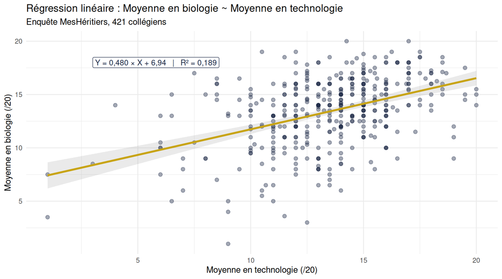

```r
ggplot(paires, aes(x = moy_techno, y = moy_bio)) +
  geom_point(color = "#1a2744", alpha = 0.4, size = 2) +
  geom_smooth(method = "lm", formula = y ~ x, color = "#c8a415",
              se = TRUE, alpha = 0.2, linewidth = 1.2) +
  annotate("label", x = 3, y = 18,
           label = "Y = 0,480 × X + 6,94   |   R² = 0,189",
           color = "#1a2744", fill = "white", size = 3.5, hjust = 0) +
  labs(
    title = "Régression linéaire : Moyenne en biologie ~ Moyenne en technologie",
    subtitle = paste0("Enquête MesHéritiers, ", nrow(paires), " collégiens"),
    x = "Moyenne en technologie (/20)",
    y = "Moyenne en biologie (/20)"
  ) +
  theme_minimal()
```

La dispersion du nuage autour de la droite reflète visuellement le $R^2$ faible de 0,189.

## 1.4 Q4 — Tableau croisé V0001 × V0008

On croise le **sentiment de l’enfant face à ses camarades** (V0001) et le **classement en difficulté scolaire** (V0008).

**NoteAstuce TCD Excel**

*Insertion > Tableau croisé dynamique* ; Lignes = V0001, Colonnes = V0008. Valeurs = V0008 (Nombre). Puis *Clic droit > Afficher les valeurs > % du total de la ligne*.

**Voir le code R**

```r
df_cross <- df_ct %>%
  filter(!is.na(sentiment), !is.na(difficult)) %>%
  mutate(
    sentiment = factor(sentiment,
                       levels = c("à l'aise", "ça dépend", "mal à l'aise"),
                       labels = c("À l'aise", "Ça dépend", "Mal à l'aise")),
    difficult = factor(difficult,
                       levels = c("élèves en réussite", "élèves moyens", "élèves en difficultés"),
                       labels = c("Réussite", "Moyens", "Difficultés"))
  )

tab_eff <- table(df_cross$sentiment, df_cross$difficult)
tab_eff_totaux <- addmargins(tab_eff)

# Renommer "Sum" en "Total" pour les marges
dimnames(tab_eff_totaux) <- lapply(
  dimnames(tab_eff_totaux),
  function(x) gsub("^Sum$", "Total", x)
)

kable(tab_eff_totaux, caption = "Tableau 1 — Effectifs observés (avec totaux marginaux)")
```

Tableau 1 — Effectifs observés (avec totaux marginaux)

|  | Réussite | Moyens | Difficultés | Total |
| --- | --- | --- | --- | --- |
| À l’aise | 182 | 214 | 132 | 528 |
| Ça dépend | 22 | 76 | 44 | 142 |
| Mal à l’aise | 1 | 3 | 1 | 5 |
| Total | 205 | 293 | 177 | 675 |

**Voir le code R**

```r
tab_pct <- lprop(tab_eff, digits = 1)

# Renommer "All" / "Ensemble" en "total" pour les marges
dn <- dimnames(tab_pct)
dn[[1]] <- gsub("^(All|Ensemble)$", "total", dn[[1]])
dn[[2]] <- gsub("^(All|Ensemble)$", "total", dn[[2]])
dimnames(tab_pct) <- dn

kable(tab_pct, caption = "Tableau 2 — Pourcentages en ligne")
```

Tableau 2 — Pourcentages en ligne

|  | Réussite | Moyens | Difficultés | Total |
| --- | --- | --- | --- | --- |
| À l’aise | 34.46970 | 40.53030 | 25.00000 | 100 |
| Ça dépend | 15.49296 | 53.52113 | 30.98592 | 100 |
| Mal à l’aise | 20.00000 | 60.00000 | 20.00000 | 100 |
| total | 30.37037 | 43.40741 | 26.22222 | 100 |

**Lecture.** Parmi les élèves qui se disent « à l’aise » avec leurs camarades, 34,5 % sont en réussite et 25,0 % en difficulté. À l’inverse, chez ceux qui répondent « ça dépend », seuls 15,5 % sont en réussite et 31,0 % en difficulté. Il y a donc bien un contraste, mais qu’il faut quantifier par le Khi-deux.

## 1.5 Q5 — Test du Khi-deux

**NoteMéthode**

On cherche à savoir si les deux variables sont **dépendantes** ou **indépendantes**.

- **Sur Excel** : `=TEST.CHISQ(Plage_Observée; Plage_Théorique)` renvoie directement la p-value du test.
- **Sur R** : la fonction `chisq.test()` renvoie la p-value (et accessoirement la valeur du Khi²).

**Règle de décision** : on compare la p-value au seuil standard de 0,05.

- Si p-value **< 0,05** : on rejette l’hypothèse d’indépendance → les variables sont **dépendantes**.
- Si p-value **≥ 0,05** : on ne rejette pas l’indépendance → les variables sont **indépendantes**.

**Voir le code R**

```r
test <- chisq.test(tab_eff)
```

**Voir le code R**

```r
test$p.value
```

```
[1] 0.0005668498
```

**ImportantConclusion**

La p-value est **nettement inférieure au seuil de 0,05** (p < 0,001).

On **rejette l’hypothèse d’indépendance** : le sentiment d’aisance avec les camarades et le classement en difficulté scolaire **sont dépendants**. Il existe un lien statistique entre les deux variables.

Attention : ce test nous dit **qu’un** lien existe, mais il ne dit rien sur sa **force** ni sur **l’endroit** où il se concentre. C’est à ces questions que répondent le V de Cramer (bonus B1) et l’analyse des résidus (Q6). Ici, comme on va le voir, l’effet est en réalité **faible**.

## 1.6 Q6 — Résidus standardisés et visualisation

Le Khi-deux nous dit qu’**un** lien existe ; les **résidus** nous disent **où** il se concentre.

**NoteFormule du résidu standardisé**

$$r_{ij} = \frac{O_{ij} - T_{ij}}{\sqrt{T_{ij}}}$$

**Règle du ±2** : $|r| < 2$ = bruit statistique ; $r > +2$ = sur-représentation ; $r < -2$ = sous-représentation.

**Voir le code R**

```r
# Reconstruction des effectifs théoriques à partir du tableau observé
totaux_lignes <- rowSums(tab_eff)
totaux_cols   <- colSums(tab_eff)
n_total       <- sum(tab_eff)
tab_theo      <- outer(totaux_lignes, totaux_cols) / n_total

residus <- (tab_eff - tab_theo) / sqrt(tab_theo)
kable(round(residus, 2), caption = "Tableau 5 — Résidus standardisés")
```

Tableau 5 — Résidus standardisés

|  | Réussite | Moyens | Difficultés |
| --- | --- | --- | --- |
| À l’aise | 1.71 | -1.00 | -0.55 |
| Ça dépend | -3.22 | 1.83 | 1.11 |
| Mal à l’aise | -0.42 | 0.56 | -0.27 |

**Voir le code R**

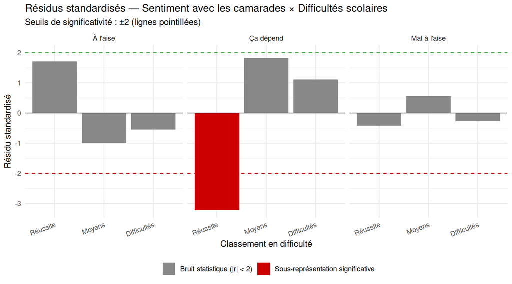

```r
df_res <- as.data.frame(as.table(residus)) %>%
  rename(Sentiment = Var1, Classement = Var2, Residu = Freq) %>%
  mutate(Sens = case_when(
    Residu >  2 ~ "Sur-représentation significative",
    Residu < -2 ~ "Sous-représentation significative",
    TRUE        ~ "Bruit statistique (|r| < 2)"
  ))

ggplot(df_res, aes(x = Classement, y = Residu, fill = Sens)) +
  geom_bar(stat = "identity") +
  geom_hline(yintercept =  2, linetype = "dashed", color = "#2ca02c") +
  geom_hline(yintercept = -2, linetype = "dashed", color = "#cc0000") +
  geom_hline(yintercept =  0, color = "black", linewidth = 0.3) +
  facet_wrap(~ Sentiment) +
  scale_fill_manual(values = c(
    "Sur-représentation significative"   = "#2ca02c",
    "Sous-représentation significative"  = "#cc0000",
    "Bruit statistique (|r| < 2)"        = "#888888"
  )) +
  labs(
    title = "Résidus standardisés — Sentiment avec les camarades × Difficultés scolaires",
    subtitle = "Seuils de significativité : ±2 (lignes pointillées)",
    x = "Classement en difficulté",
    y = "Résidu standardisé",
    fill = ""
  ) +
  theme_minimal() +
  theme(legend.position = "bottom",
        axis.text.x = element_text(angle = 20, hjust = 1))
```

### 1.6.1 Lecture des résidus

Une **seule** case dépasse le seuil de ±2 :

| Case | Résidu | Interprétation |
| --- | --- | --- |
| **Ça dépend × Réussite** | **−3,22** | Forte sous-représentation : les élèves au sentiment ambivalent (« ça dépend ») sont très significativement moins nombreux que prévu en réussite scolaire. |

**Synthèse.** Le signal statistique est **limité** : si le lien global est significatif (Khi² significatif, p < 0,001), il tient essentiellement à **un** décalage — l’ambivalence relationnelle s’accompagne d’une moindre réussite. Cette configuration invite à rappeler une règle d’or de la méthode : **significativité ≠ force d’effet**.

# 2 Partie 2 : Analyse rédigée

## 2.1 Introduction

Les données mobilisent à la fois des variables quantitatives (notamment les moyennes par matière) et qualitatives (relation à l’école, rapports aux camarades et aux enseignants, parcours scolaire antérieur). Nous les mobilisons ici pour interroger deux dimensions complémentaires : le **talent scolaire transversal** (à travers les moyennes en biologie et technologie) et le **sentiment d’aisance avec les camarades** (comme marqueur possible de difficulté).

## 2.2 Problématique

**Au sein de familles fortement diplômées, le talent scolaire est-il transversal entre disciplines et le sentiment d’aisance avec les camarades prédit-il les difficultés scolaires ?**

Deux hypothèses structurent l’analyse :

1. **Hypothèse quantitative (Q1–Q3)** : le talent scolaire est un trait global ; un élève fort en biologie le serait aussi en technologie. Une forte corrélation entre ces deux moyennes le confirmerait.
2. **Hypothèse qualitative (Q4–Q6)** : les difficultés scolaires ne sont pas seulement cognitives mais aussi **sociales**. Les élèves mal à l’aise avec leurs camarades seraient sur-représentés dans les difficultés scolaires.

## 2.3 Le talent scolaire : faiblement transversal

L’analyse bivariée biologie × technologie ne conforte pas l’idée d’un talent scolaire global. Le coefficient de corrélation ($r = 0{,}435$) signale un lien positif **modéré**, et le coefficient de détermination ($R^2 = 0{,}189$) précise que **la technologie n’explique que 19 %** de la variance des notes en biologie. Les **81 % restants** dépendent d’autres facteurs — caractéristiques personnelles, rapport à la discipline, pédagogie.

La régression ($\widehat{Y} = 0{,}480 \times X + 6{,}94$) confirme cette tendance modeste : chaque point gagné en technologie s’accompagne en moyenne de 0,48 point gagné en biologie. La dispersion importante autour de la droite de régression traduit l’hétérogénéité réelle des profils.

Ces résultats invitent à **abandonner la notion de « bon élève scientifique » comme catégorie homogène**. Même dans un échantillon d’héritiers où l’on pourrait attendre une certaine homogénéité culturelle, les compétences disciplinaires restent largement **autonomes**. Un élève peut parfaitement briller en biologie sans performer en technologie, et inversement.

## 2.4 Le sentiment d’aisance avec les camarades : un lien significatif mais faible

La seconde hypothèse trouve une **validation partielle** dans l’analyse qualitative. Le test du Khi-deux ($\chi^2 \approx 19{,}7$, $p < 0{,}001$) rejette l’hypothèse d’indépendance entre sentiment avec les camarades et classement scolaire. Un lien statistique existe donc, au-delà du hasard d’échantillonnage.

Cependant, l’examen des résidus standardisés **nuance fortement** cette première conclusion. Sur les neuf cases du tableau, **une seule** dépasse le seuil de significativité de ±2 : la case « Ça dépend × Réussite » affiche un résidu de **−3,22**, signe d’une sous-représentation forte. Les élèves dont le sentiment est ambivalent avec leurs camarades sont beaucoup moins nombreux que prévu parmi les élèves en réussite.

Le signal principal est donc **asymétrique** : c’est essentiellement du côté de la **non-réussite** que le sentiment d’ambivalence se concentre. Être ambivalent avec ses camarades n’accentue pas nécessairement les difficultés scolaires, mais **semble bloquer l’accès à la réussite**.

Ce résultat, à manier avec prudence compte tenu de la faiblesse globale de l’effet (voir V de Cramer en bonus), suggère que l’intégration sociale au collège — plus précisément le sentiment d’**appartenir au groupe** — pourrait être une condition facilitante (mais non suffisante) de la réussite scolaire. Inversement, un sentiment d’extériorité, même mesuré, pourrait constituer un frein discret à l’accès à la réussite.

## 2.5 Conclusion

Cette analyse croise deux registres — quantitatif (moyennes par matière) et qualitatif (sentiment relationnel) — pour interroger la réussite scolaire dans les familles fortement diplômées.

**D’une part**, le talent scolaire n’est pas un trait global : la corrélation entre la biologie et la technologie reste modérée ($r = 0{,}44$, $R^2 = 0{,}19$). Les disciplines mesurent des compétences largement indépendantes, y compris au sein d’un même « pôle scientifique ».

**D’autre part**, le sentiment d’aisance avec les camarades est significativement associé au classement en difficulté scolaire, mais l’effet reste faible ($\chi^2$ significatif, $p < 0{,}001$ ; mais un seul résidu dépasse le seuil ±2). Le signal principal concerne les élèves **ambivalents** dans leur rapport aux camarades, qui sont significativement sous-représentés parmi ceux en réussite.

### 2.5.1 Limites

1. **Corrélation n’est pas causalité.** Le sentiment d’ambivalence peut être une **conséquence** autant qu’une cause de la non-réussite scolaire (les élèves qui réussissent moins peuvent développer un rapport complexe à leurs camarades).
2. **Effet de taille d’échantillon.** La modalité « mal à l’aise » ne compte que 5 individus : toute interprétation de cette ligne est fragile.
3. **Sentiment auto-rapporté.** Les réponses peuvent être biaisées par la désirabilité sociale.
4. **Non-réponses sur les moyennes.** Environ 35 % de l’échantillon n’a pas renseigné les moyennes en biologie ou technologie, ce qui peut introduire un biais de sélection.

**AstuceBonne pratique**

Discuter les limites fait partie d’une analyse rigoureuse. Un résultat statistiquement significatif peut rester **pratiquement faible**, et c’est à l’analyste de faire cette distinction pour le lecteur.

# 3 Bonus

## 3.1 B1 — V de Cramer

**NoteFormule**

$$V = \sqrt{\frac{\chi^2}{n \times \min(k - 1,\ l - 1)}}$$

**Voir le code R**

```r
cramer_v <- cramer.v(tab_eff)
tibble(
  Indicateur = c("Khi²", "n", "min(k-1, l-1)", "V de Cramer"),
  Valeur = c(round(test$statistic, 2),
             sum(tab_eff),
             min(nrow(tab_eff) - 1, ncol(tab_eff) - 1),
             round(cramer_v, 3))
) %>% kable(align = "lr")
```

| Indicateur | Valeur |
| --- | --- |
| Khi² | 19.720 |
| n | 675.000 |
| min(k-1, l-1) | 2.000 |
| V de Cramer | 0.121 |

**ImportantInterprétation**

**V ≈ 0,121** : effet **faible**.

| V de Cramer | Intensité |
| --- | --- |
| < 0,10 | effet nul ou très faible |
| 0,10 – 0,20 | **effet faible** ← nous sommes ici |
| 0,20 – 0,30 | effet modéré |
| > 0,30 | effet fort |

Ce résultat est **cohérent** avec l’analyse des résidus : une seule case dépassait ±2, les autres restaient dans le bruit. La significativité statistique (p < 0,001) tient essentiellement à la taille de l’échantillon (n = 675), qui permet de détecter des effets même ténus. **Significativité ≠ force d’effet.**

## 3.2 B2 — PEM (Pourcentage de l’Écart Maximum)

**NoteFormule de Cibois**

1. Écart à l’indépendance : $E = O - T$
2. Effectif maximum compatible : $M = \min(\text{Total ligne},\ \text{Total colonne})$
3. Écart maximum : $E_{\max} = M - T$
4. PEM (%) = $\dfrac{E}{E_{\max}} \times 100$

On identifie la case avec le **résidu positif maximal** :

**Voir le code R**

```r
df_res_pos <- df_res %>% filter(Residu > 0) %>% arrange(desc(Residu))
kable(df_res_pos,
      caption = "Classement des cases en attraction (résidu > 0)")
```

Classement des cases en attraction (résidu > 0)

| Sentiment | Classement | Residu | Sens |
| --- | --- | --- | --- |
| Ça dépend | Moyens | 1.8292503 | Bruit statistique (\|r\| < 2) |
| À l’aise | Réussite | 1.7092455 | Bruit statistique (\|r\| < 2) |
| Ça dépend | Difficultés | 1.1085447 | Bruit statistique (\|r\| < 2) |
| Mal à l’aise | Moyens | 0.5631412 | Bruit statistique (\|r\| < 2) |

La case la plus saillante (résidu positif maximal) est **« Ça dépend × Moyens »** ($r = +1{,}83$, juste sous le seuil de significativité).

**Voir le code R**

```r
i <- which(rownames(tab_eff) == "Ça dépend")
j <- which(colnames(tab_eff) == "Moyens")

O    <- tab_eff[i, j]
T    <- totaux_lignes[i] * totaux_cols[j] / n_total
E    <- O - T
M    <- min(totaux_lignes[i], totaux_cols[j])
Emax <- M - T
PEM  <- E / Emax * 100

tibble(
  Étape = c(
    "Observé O",
    "Théorique T",
    "Écart E = O − T",
    "Effectif max compatible M = min(L, C)",
    "Écart maximum Emax = M − T",
    "PEM = E / Emax × 100"
  ),
  Valeur = c(
    O,
    round(T, 2),
    round(E, 2),
    M,
    round(Emax, 2),
    paste0(round(PEM, 1), " %")
  )
) %>% kable(align = "lr")
```

| Étape | Valeur |
| --- | --- |
| Observé O | 76 |
| Théorique T | 61.64 |
| Écart E = O − T | 14.36 |
| Effectif max compatible M = min(L, C) | 142 |
| Écart maximum Emax = M − T | 80.36 |
| PEM = E / Emax × 100 | 17.9 % |

**ImportantInterprétation**

**PEM ≈ 18 %** : la case « Ça dépend × Moyens » atteint environ 18 % de son attraction maximale possible compte tenu des marges.

C’est un résultat **modeste**, en ligne avec le V de Cramer global (0,12) : l’échantillon ne permet pas de mettre en évidence d’attraction locale très forte dans ce tableau. La plus forte structure du tableau reste la **sous-représentation** (résidu −3,22) détectée en Q6 — qui, pour être mesurée par un PEM, nécessiterait l’extension de l’indice aux cas de répulsion (voir annexe de Cibois, 1993).

Cette configuration est **pédagogiquement précieuse** : elle illustre qu’un tableau peut être globalement **significatif** tout en étant localement **faiblement structuré**. Le PEM permet alors de confirmer que le lien observé reste d’une intensité limitée.

# 4 Annexe : Erreurs fréquentes à éviter

**Important1. Ne pas commenter chaque indicateur (Q1)**

Chaque indicateur devait être accompagné d’un commentaire explicatif. Aligner les chiffres sans interpréter ne valide que la moitié de la question.

**Important2. Confondre p-value et force du lien**

Un $p < 0{,}001$ ne signifie **pas** que le lien est fort. Il signifie que le lien n’est très probablement pas dû au hasard. La force se mesure avec le V de Cramer — ici 0,12, soit un effet **faible**.

**Important3. Confondre Y, $\widehat{Y}$ et X dans la régression**

Y = variable à expliquer ; $\widehat{Y}$ = valeur prédite par le modèle ; X = variable explicative. Un élève peut avoir un $\widehat{Y}$ de 13 en biologie alors que sa vraie note est 17 : c’est la définition d’un résidu de régression.

**Important4. Sur-interpréter les résidus qui ne dépassent pas ±2**

Corrélation n’est pas causalité. Un échantillon spécifique n’est pas généralisable. Les modalités à faible effectif (ici « Mal à l’aise », n=5) sont fragiles. Une analyse professionnelle se reconnaît à la lucidité de ses limites.